# Chapter 7

5/27/2015

## Review

- Scatterplots can show us relationships between two numeric variables.
- Correlation describes the strength and direction of linear relationships between two numeric variables.
- We call the \(X\) variable the **explanatory** variable, because it *explains* the \(Y\) variable.
- We call the \(Y\) variable the **response** because it *responds* to changes in \(X\).

Where do we go from here?

- If correlation tells us how well the points fit around a line, what line do they fit around?
- How can we use this line to describe the relationship further?
- Can we use it to make predictions?

## Fuel Efficiency vs. Weight

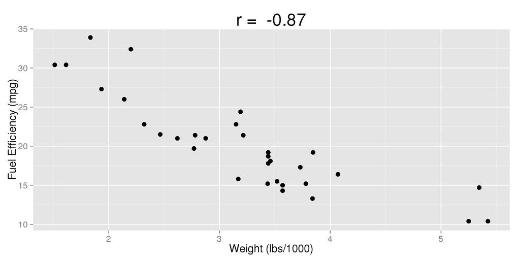

## Fuel Efficiency vs. Weight

What can we see?

- \(r = -0.87\)
- There is a fairly strong negative linear relationship between the weight of a car and its fuel efficiency
- As we increase the weight of a car, the fuel efficiency tends to decrease.

What else might we want to do?

- Describe the general trend with a line
- Make a prediction of what the fuel efficiency of a car weighing 4500 lbs is.

## The Line of Best Fit

So how do we find the line the best describes the general trend?

- The most commonly used method is called the **least squares regression** (LSR).
- The **least squares regression line** is the line that comes closest to **all** of the points simultaneously.
- At any value of the \(X\) variable, the line is our prediction for the **mean** or **expected** value of the \(Y\) variable.
- This lets us analyze values of \(Y\) *given* that we know what \(X\) is.

## Fuel Efficiency vs. Weight

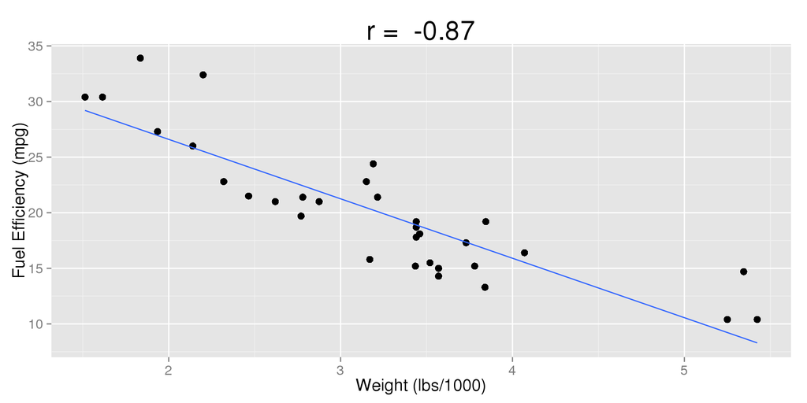

## The Linear Model

Defining Least Squares Regression:

- LSR is a **linear model**
- A mathematical model is just a formula that describes something in the real world (e.g., Area = Base \(\times\) Height)
- A statistical model does the same thing, but it accounts for variability or uncertainty (e.g., The Normal Model)
- LSR calculates the best possible line to describe the overall trend between our variables from our data

## The Least Squares Line

Recall from algebra that we can describe a line using the formula:

- \(y = mx + b\)

In statistics, we use the same method with different, but we label things differently:

- \(\hat{y} = b_0 + b_1 x\)

What do the terms mean?

- \(b_1\) \((m)\) is the slope
- \(b_0\) \((b)\) is the y-intercept
- \(\hat{y}\) is our prediction for the mean of \(Y\) when \(X = x\)

## Algebra Review: Lines

Consider the line: \(\hat{y} = 1 + 2x\)

| \(x\) | \(\hat{y} = 1 + 2x\) | \(\hat{y}\) |
| --- | --- | --- |
| \(0\) | \(\hat{y} = 1 + 2(0)\) | \(1\) |
| \(1\) | \(\hat{y} = 1 + 2(1)\) | \(3\) |
| \(2\) | \(\hat{y} = 1 + 2(2)\) | \(5\) |

What do the coefficients tell us?

- \(b_0 = 1\) tells us the value of \(\hat{y}\) when \(X = 0\)
- \(b_1 = 2\) tells us that every time \(X\) goes up by one unit, \(\hat{y}\) increases by \(2\)

## Fuel Efficiency vs. Weight

For our car data set, the regression line is:

\[ \widehat{mpg} = 37.2851 -5.3445wt\]

What does this tell us? Keep in mind that weight is in *thousands of pounds*.

- For every added 1000 pounds of weight, fuel efficiency drops by \(5.3445\) miles per gallon
- If a car weighs 0 lbs, it's predicted efficiency is \(37.285\) mpg

This brings up an important note:

- A car can't weigh 0 lbs.
- In statistics, the y-intercept is often not interpretable, we just use it to draw the line and make predictions.

## Fuel Efficiency vs. Weight

\[\widehat{mpg} = 37.2851 -5.3445wt\]

If a car weighed \(4500\) lbs, what would we expect its efficiency to be?

- \(\widehat{mpg} = 37.28511 -5.3445(4.5)\)
- \(\widehat{mpg} = 37.285 - 24.05\)
- \(\widehat{mpg} = 13.23\)

How do we interpret this?

- We predict that the *average* car weighing \(4500\) lbs gets \(13.23\) mpg

## Hitting Points

An important note:

- The Least Squares Regression line is **not** gauranteed to hit any one of our observed points
- In fact, it's entirely possible that the line will not hit **any** of our observed points
- There is only one place that we **know** the line will pass through: \((\bar{x}, \bar{y})\)

## Hitting Points

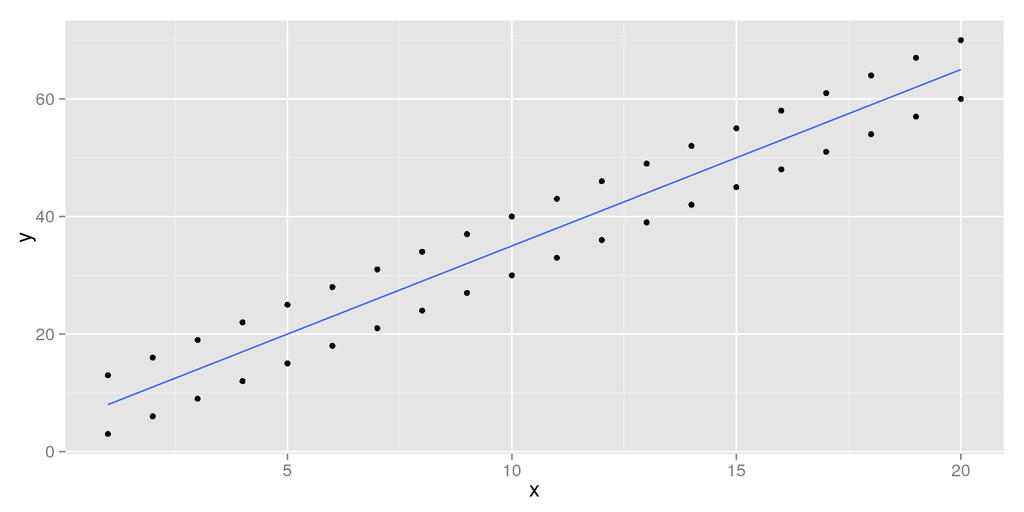

## Residuals

We said the the Least Squares Regression line doesn't hit every point in our scatterplot, so how can we tell how well it does?

- For each point \((x, y)\), we predict the value \((x, \hat{y})\)
- For every observation we have, we can see how far off we were by finding the **residual**
- For a given \(x\), the residual is: \(y - \hat{y}\)
- This is the *vertical* distance between the line and the true value of \(y\).
- If our estimate was too **high**, the residual will be **negative**
- If our estimate was too **low**, the residual will be **positive**

## Residuals: Example

Let's pick on car in our data set, the Camaro Z28. This car gets \(13.3\) mpg and weighs \(3840\) lbs.

- \(\widehat{mpg} = 37.2851 -5.34455wt\)
- \(\widehat{mpg} = 37.2851 -5.3445(3.84)\)
- \(\widehat{mpg} = 37.2851 - 20.5228\)
- \(\widehat{mpg} = 16.76\)

So how'd we do?

- \(mpg - \widehat{mpg} = 13.3 - 16.76 = -3.46\)
- We *overestimated* by 3.46 mpg

## Visualizing Residuals

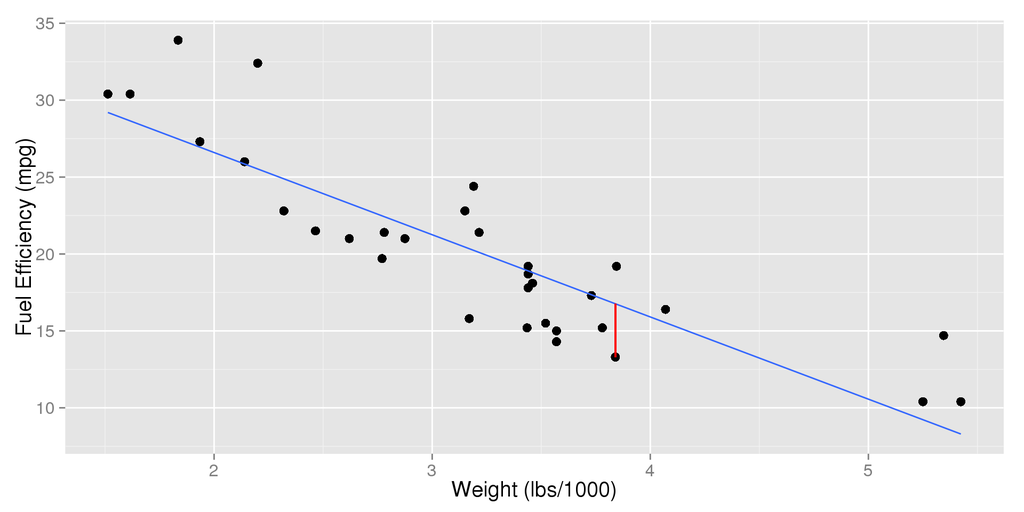

## Residuals: Example

Let's pick another car, the Fiat 128. It's efficiency is \(32.4\) mpg and it weights \(2200\) lbs.

- \(\widehat{mpg} = 37.2851 -5.34455wt\)
- \(\widehat{mpg} = 37.2851 -5.3445(2.2)\)
- \(\widehat{mpg} = 37.2851 - 11.76\)
- \(\widehat{mpg} = 25.53\)

So how'd we do?

- \(mpg - \widehat{mpg} = 32.4 - 25.53 = 6.87\)
- The model *underestimated* by 6.87 mpg

## Visualizing Residuals

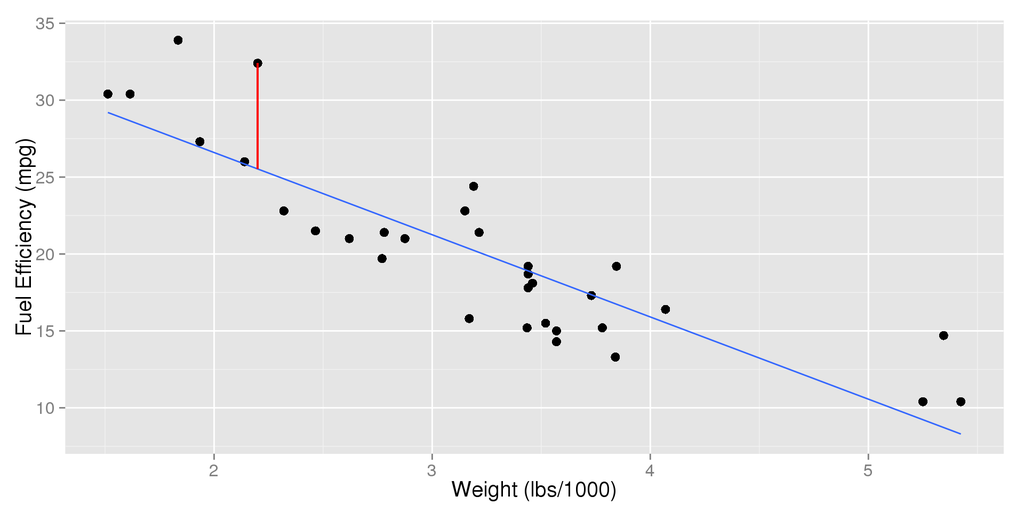

## Residuals in Reverse

Imagine you bought a car that weighs \(2780\) pounds, and I told you the residual was \(-1.03\). What was the car's fuel efficiency?

- \(mpg - \widehat{mpg} = -1.03\)
- \(\widehat{mpg} = 37.2851 -5.34455wt\)
- \(\widehat{mpg} = 37.2851 -5.3445(2.78)\)
- \(\widehat{mpg} = 37.2851 - 14.86\)
- \(\widehat{mpg} = 22.43\)
- \(mpg - 22.43 = -1.03\)
- \(mpg = -1.03 + 22.43 = 21.4\)

## The Least Squares Line

We've seen how to check the prediction for a single value, but how do we know we did the best we could?

- The LSR line comes the closest to **all** of the points simultaneously
- It does this by finding the line which has the smallest residuals overall
- Since negative residuals are just as important as positive ones, we square them to force them to be positive
- Because of this, we focus on the *squared* residuals

We call our line the Least Squares Regression line because it:

- **Minimizes the sum of the squared residuals**
- This means that it minimizes the sum of the squared vertical distances between the points and the line.

## Relationship to Correlation

Recall:

- Correlation is the **strength** of the **linear relationship** between \(X\) and \(Y\).
- \(-1 \le r \le 1\)
- The direction of the relationship is indicated by the **sign** of \(r\)

Because of this,

- The sign of \(r\) will always match the sign of \(b_1\).

## Measure of Fit: \(R^2\)

In order to evaluate how good the model is, we need a measurement of how well it fits. For this, we use the \(R^2\) statistic.

- \(R^2\) is the fraction of the variability in the response \((Y)\) variable exlained by the \(X\) variable.
- Do changes in \(X\) explain changes in \(Y\)?

So what is \(R^2\)?

- If we only have one \(X\) variable, \(R^2 = r^2\)
- \(-1 \le r \le 1 \quad \to \quad 0 \le R^2 \le 1\)
- If \(R^2 = 1\), knowing \(X\) lets us perfectly predict \(Y\)
- If \(R^2 = 0\), \(X\) tells us nothing about \(Y\)

## Fuel Efficiency vs. Weight

What is the \(R^2\) of our model that predicts fuel efficiency from weight?

- \(r = -0.87\), there is a strong negative correlation
- \(R^2 = (-0.87)^2\)
- \(R^2 = 0.76\)
- So the weight of cars explains 76% of the variability in their fuel efficiency
- This makes sense, obviously other properties (number of cylinders, transmission, design, etc.) will play a role in a car's fuel efficiency

## Units in Regression

In Correlation:

- The correlation coefficient has no units
- Changes in units (e.g., lbs \(\to\) kg) had no effect on \(r\)

In Regression:

- The slope is "rise over run", or "change in \(Y\) over change in \(X\)"
- The slope is measured in units of \(Y\) over units of \(X\)
- Changing units can significantly change our line

## Fuel Efficiency vs. Weight: Changes in Units

So far, we've been measuring the weight in 1000s of pounds

- \(b_1 = -5.3445\)
- This represents how much the fuel efficiency in mpg changes when we increase weight by 1000 pounds

What if we represented the weight directly in pounds?

- The same relationship needs to exist, so changing the weight by 1000 pounds still needs to move mpg down by 5.3445
- In order for this to be true, the slope needs to be divided by 1000
- \(b_1 = -5.3445/1000 = -0.0053445\)
- So changing increasing the weight by a single pound decreases mpg by 0.0053445.

## Regression: Outliers

How do outliers affect regression?

If they fall along the line, but are extreme in \(X\)

- They can inflate \(R^2\) and make us think the relationship is stronger than it really is

## Fuel Efficiency vs. Weight

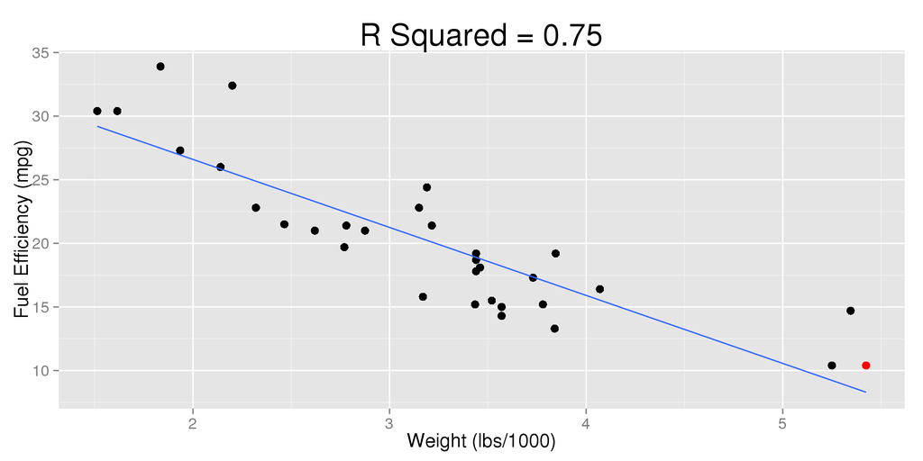

## Fuel Efficiency vs. Weight

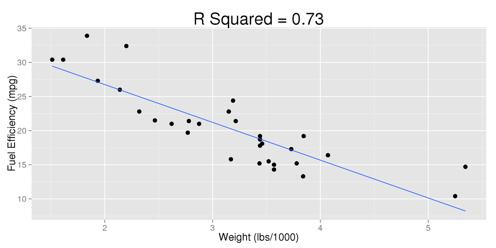

## Horsepower vs. Engine Displacement

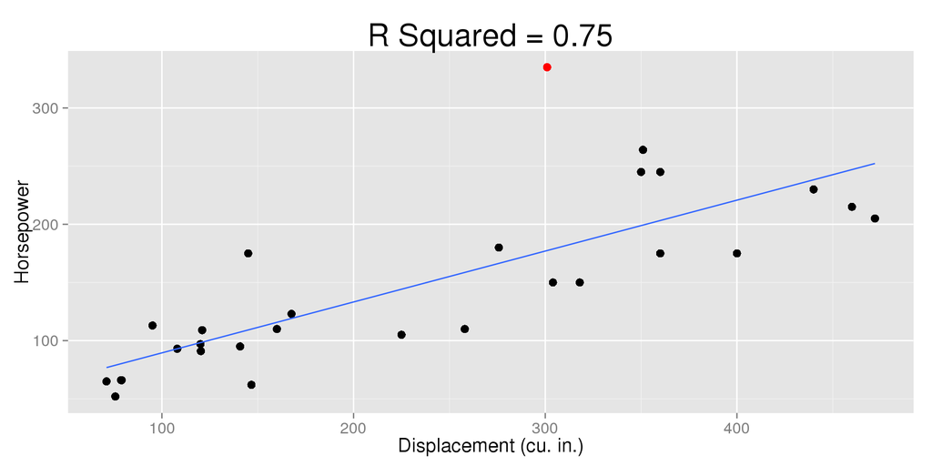

## Horsepower vs. Engine Displacement

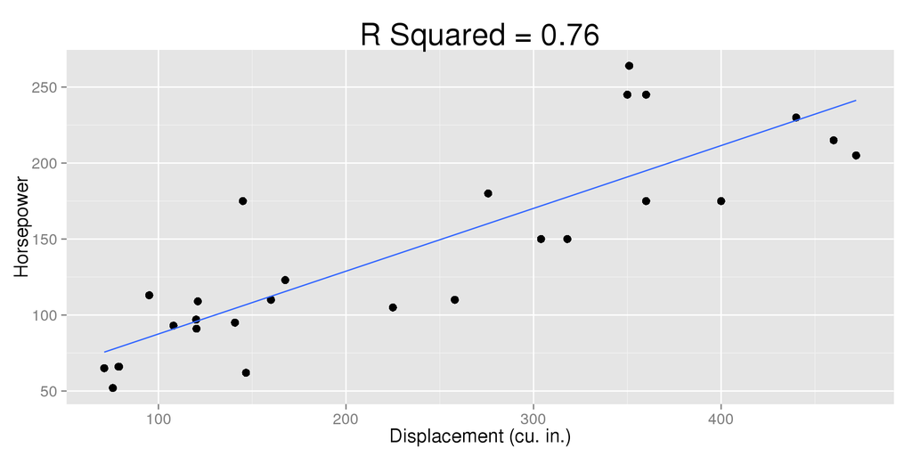

## Using StatCrunch

To do regression in StatCrunch:

1. `Stat` \(\to\) `Regression` \(\to\) `Simple Linear`
2. `X Variable` \(\to\) Select your explanatory variable
3. `Y Variable` \(\to\) Select your response

## StatCrunch: Regression Results

[figure not shown]

## StatCrunch: Regression Results

[figure not shown]

## Extending Regression: Multiple \(X\)'s

Why do statisticians use \(\hat{y} = b_0 + b_1x\) instead of \(y = mx + b\)?

- Because we can also try to use multiple \(X\) variables to predict a single \(Y\)
- For example, we could use mothers' and fathers' heights to find a model for thei childens' heights
- \(\widehat{\text{child's}} = b_0 + b_1\left(\text{mother}\right) + b_2\left(\text{father}\right)\)
- This is called multiple regression
- \(R^2\) then takes all of the \(X\) variables into account

## Extending Regression: Variable Types

Categorical Variables can be used in regression using what are called *dummy variables*. Say we wanted to use gender to predict height.

- Let \(x = 0\) if the person is male
- Let \(x = 1\) if the person is female

If we had a model \(\hat{h} = 5.7ft - 0.25x\)

- \(\hat{h} = 5.7ft - 0.25(0) = 5.7ft\) if a person is male
- \(\hat{h} = 5.7ft - 0.25(1) = 5.45ft\) if a person is female

This is often done in medical trials, especially in multiple regression.

## Summary

- We can describe the linear relationship between two numeric variables with Least Squares Regression
- We get predictions for a value of the explanatory variable by plugging its value in for \(x\) in the line equation
- The prediction is our estimation of the *average* response for that value of \(X\)
- A residual is the distance from the true value of \(Y\) we observed from the prediction
- The Least Squares regression line minimizes the sum of the squared residuals
- \(R^2\) is the fraction (or percent) of the variability in the response explained by the regression model
- Outliers can have a significant effect on the slope of the line and \(R^2\)